# Week #4 Summary

**Solution to reading files (such as .csv) on Rmarkdown documents:**

Install the RCurl package

> Use getUrL() function:

```r
require(RCurl)
raw <- getURL("https://raw.github.com/PermuteSeminar/PermuteSeminar-2014/master/Week-2/ClutchSize.csv")
```

```
## Error: SSL certificate problem, verify that the CA cert is OK. Details:
## error:14090086:SSL routines:SSL3_GET_SERVER_CERTIFICATE:certificate verify failed
```

```r
clutch <- read.csv(text = raw)  #make sure to upload RAW data file
```

```
## Error: invalid 'text' argument
```

# Lecture Notes

## *adapted from Emily Rollinsion*

> For this week, we read Chapter 8 in Efron and Tibshirani, and notes on bootstrapping dependent data (Steigerwald; posted to GitHub and on Blackboard). This chapter provides an overview of bootstrapping procedues for more complicated data structures than the one-sample model, such as time-dependent data or otherwise non-IID data.

## In-class discussion:

The goal of the bootstrap algorithm is to estimate the probability distribution that underlies our data. We can use our empirical distribution in lieu of the full distribution to understand the distribution of statisics of interest (mean, variance, etc.).

Bootstraps are often used to estimate standard errors. We select \( B \) independent bootstrap samples, calculate our test statistic using the bootstrap samples, and use the standard deviation of the \( B \) replications as an estimate of the standard error of the unknown distribution \( F \) that underlies our empirical data. Resampled populations should equal the number of orginal samples. *'s are used to indicate resampled items.

This works for both a single unknown distribution (see Figure 8.1 in E&T) or a more complicated underlying process or a whole set of unknown distributions (see Figure 8.3 in E&T). We could easily imagine some biological measure influenced by many processes (i.e., many underlying and unknown statistical distributions).

## Today's example:

We used the data from Leutenizing hormone example in Efron and Tibshirani (Ch. 8). This formed a time series with some temporal stucture. the whole distirbution may be normal.

We will model this using an autoregressive model of period 1. \[ AR(1): z_{t} = \beta_{z_{t-1}} + \epsilon_{t} \]

> where \( z_{t} \) has an expectation 0 and \( \beta \) is an unknown parameter, a number between -1 and 1.

# In class Excercises

**Use dataset from book:**

> **1. Estimate \( \hat{\beta} \) **

## Solution: Adapted from Jon Borrelli

Load Required Packages

```r
require(RCurl)
require(ggplot2)
```

Load Dataset:

```r
rawURL <- getURL("https://raw.github.com/PermuteSeminar/PermuteSeminar-2014/master/Week-4/hormone_data.csv")
```

```
## Error: SSL certificate problem, verify that the CA cert is OK. Details:
## error:14090086:SSL routines:SSL3_GET_SERVER_CERTIFICATE:certificate verify failed
```

```r
setwd("C:/Users/admin/Google Drive/Courses_Seminars/Stats_Seminar/PermuteSeminar-2014/Week-4")
hormone <- read.csv("hormone_data.csv")
# hormone <- read.csv(text = rawURL)
```

Calculate \( z_t \) for each data point: \( z_t = y_t-\mu \)

```r
z.t <- hormone$level - mean(hormone$level)
```

Calculate residual squared errors for each value of \( z_t \) and all possible values of \( b \). \[ RSE(b) = \sum_{t-U}^{V}(z_t - bz_{t-1})^2 \]

Generate a function that does this calculation over these values and picks out the best value for \( b \) that minimizes RSE.

```r
rse <- function(zt, b) {
    est.b <- c()
    for (i in 1:length(b)) {
        res <- c()
        for (j in 2:length(zt)) {
            res[j - 1] <- (zt[j] - b[i] * zt[j - 1])^2  #RSE equation
        }
        est.b[i] <- sum(res)
    }
    bhat <- b[which.min(est.b)]
    return(bhat)
}
```

Run the function and get \( \hat{\beta} \)

```r
b <- seq(-1, 5, 0.001)  #generates a sequence of possible values for b
bhat <- rse(z.t, b)  #runs the function
```

**So our estimate of \( \hat{\beta} \) is 0.586**

> 2a. See how good our estimate of \( \hat{\beta} \) is by figuring out its confidence interval (Standard error) by bootstrapping

We need to estimate \( P = (\beta,F) \) from the data.

Now that we have \( \hat{\beta} \) we can use it to estimate \( F \) distribution of the distubances and calculate \( \epsilon_{t} = z_{t} - \beta_z_{t-1} \) for every \( t \)

```r
eps <- c()  #collects all the calculate values of epsilon

for (i in 1:length(z.t)) {
    eps[i] <- z.t[i] - bhat * z.t[i - 1]
}
```

A histrogram of the approximate disturbances. The Mean = 0.0062

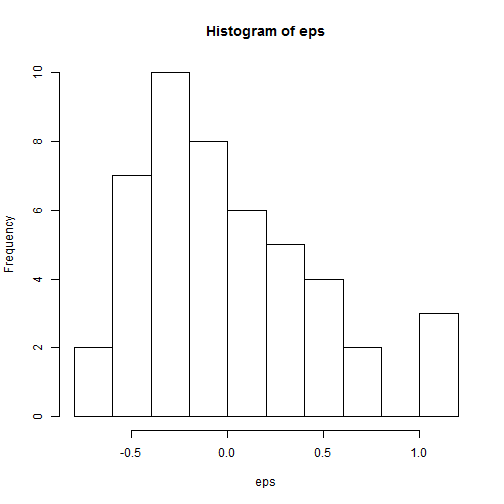

```r
hist(eps)
```

Resample these values of \( \epsilon \) with replacement:

```r
boot.eps <- matrix(nrow = 200, ncol = 47)
for (rep in 1:200) {
    boot.eps[rep, ] <- sample(eps[2:48], 47, replace = T)
}
```

Generate bootstrap for time series \( z_{t}* \)

```r
z.tmat <- matrix(nrow = 200, ncol = 48)
z.tmat[, 1] <- z.t[1]
for (rep in 1:200) {
    for (cols in 1:47) {
        z.tmat[rep, cols + 1] <- bhat * z.tmat[rep, cols] + boot.eps[rep, cols]
    }
}
z.tmat
```

[output not shown]

[output cut: 1593 more lines]

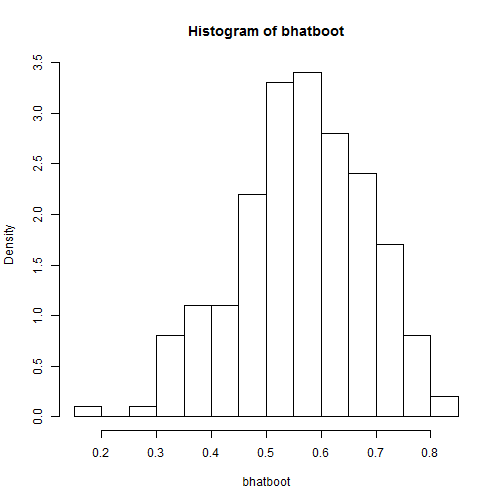

```r
b.test <- seq(0, 1, 0.001)
bhatboot <- apply(z.tmat, 1, rse, b = b.test)

hist(bhatboot, freq = F)
```

```r
mean(bhatboot)
```

```
## [1] 0.5663
```

> 2b. Use a moving blocks

```r
head(hormone)
```

```
##   period level
## 1      1   2.4
## 2      2   2.4
## 3      3   2.4
## 4      4   2.2
## 5      5   2.1
## 6      6   1.5
```

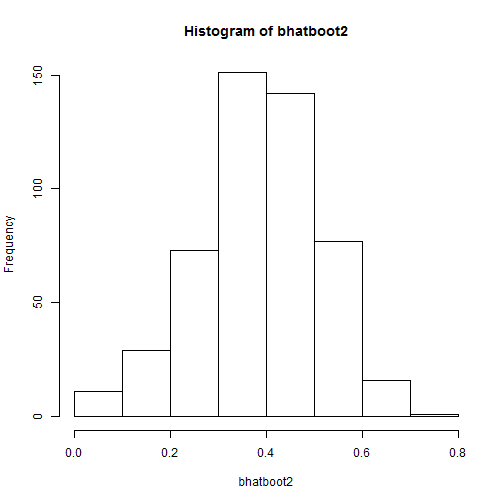

```r
block <- matrix(nrow = 3, ncol = 46)
for (i in 1:46) {
    block[1, i] <- z.t[i]
    block[2, i] <- z.t[i + 1]
    block[3, i] <- z.t[i + 2]
}

boot.block <- matrix(nrow = 500, ncol = 48)
for (i in 1:500) {
    bcol <- sample(1:46, 16, replace = T)
    boot.block[i, ] <- as.vector(block[, bcol])
}


b.test <- seq(0, 1, 0.001)

bhatboot2 <- apply(boot.block, 1, rse, b = b.test)
hist(bhatboot2)
```

```r
mean(bhatboot2)
```

```
## [1] 0.3865
```

> 1. Sample with replacement from random deviations or do a moving blocks bootstrap (with replacement chunks of the data)

## Solutions from Jesse Wolfhagen:

Step 1: Find beta-hat using Equation (8.20)

```r
# data <- read.csv('hormone_data.csv')

raw <- getURL("https://raw.github.com/PermuteSeminar/PermuteSeminar-2014/master/Week-4/hormone_data.csv")
```

```
## Error: SSL certificate problem, verify that the CA cert is OK. Details:
## error:14090086:SSL routines:SSL3_GET_SERVER_CERTIFICATE:certificate verify failed
```

```r
hormone <- read.csv("hormone_data.csv")
```

```
## Error: cannot open the connection
```

```r
data <- read.csv(text = raw)
```

```
## Error: invalid 'text' argument
```

```r
brange <- seq(0.1, 1, by = 0.001)
RSEresults <- c()
resids <- data$level - mean(data$level)
```

```
## Error: object of type 'closure' is not subsettable
```

```r
for (j in 1:length(brange)) {
    b <- brange[j]
    formula <- c()
    for (i in 1:(length(data$level) - 1)) {
        formula <- c(formula, (resids[i + 1] - b * resids[i])^2)
    }
    RSEresults <- c(RSEresults, sum(formula))
}
```

```
## Error: object of type 'closure' is not subsettable
```

[figure not shown]

```r
beta.hat <- brange[which.min(RSEresults)]
plot(x = brange, y = RSEresults)
```

```r
epsilons <- c()  #these are the empirical epsilons
for (k in 2:length(resids)) {
    epsilons <- c(epsilons, resids[k] - beta.hat * resids[k - 1])
}
```

```
## Error: object 'resids' not found
```

```r
beta.star <- c()  #boot-strapped collection of beta estimates
for (l in 1:500) {
    epsilon.star <- sample(epsilons, length(epsilons), replace = T)
    resid.star <- rep(0, times = length(resids))
    for (m in 2:length(resids)) {
        resid.star[m] <- beta.hat * resid.star[m - 1] + epsilon.star[m - 1]
    }
    # Now use the bootstrap-created residuals to re-estimate beta-hat
    # (bootstrap)
    RSEstar <- c()
    for (n in 1:length(brange)) {
        b <- brange[n]
        formula <- c()
        for (o in 1:length(resid.star) - 1) {
            formula <- c(formula, (resid.star[o + 1] - b * resid.star[o])^2)
        }
        RSEstar <- c(RSEstar, sum(formula))
    }
    beta.star <- c(beta.star, brange[which.min(RSEstar)])
}
```

```
## Error: object 'resids' not found
```

```r
hist(beta.star)
```

```
## Error: 'x' must be numeric
```

```r
sd(beta.star)
```

```
## [1] NA
```

```r
beta.star.window <- c()
for(p in 1:200) #bootstrapping
{
  #Resample beginnings of chunks (chunk length of three, can't select last two datapoints)
  indices <- sample(1:(length(data$level) - 2), length(data$level)/3, replace = T)
  #Create the new time series
  level.star <- c()
  for(q in 1:length(indices))
  {
    level.star <- c(level.star, data$level[indices[q]:(indices[q]+2)])
  }
  resids.star <- level.star - mean(level.star)
  #Recalculate beta using new residuals
  RSE.star <- c()
  for(r in 1:length(brange))
  {
    b <- brange[r]
    formula <- c()
    for(s in 1:length(resids.star) - 1)
    {
      formula <- c(formula, (resids.star[s+1] - b*resids.star[s])^2)
    }
    RSE.star <- c(RSE.star, sum(formula))
  }
  beta.star.window <- c(beta.star.window, brange[which.min(RSE.star)])
}
```

```
## Error: object of type 'closure' is not subsettable
```

```r
hist(beta.star.window)
```

```
## Error: 'x' must be numeric
```

```r
sd(beta.star.window)
```

```
## [1] NA
```